# Script that generates Fig 3

# REPRODUCING FIG 3

Here, we first try to reproduce the results presented in Fig. 3. The code to produce this figure seem to be in `emai_code.R`, from line 500. The result of this analysis should then be stored in object `kappa_taxa_sim.RData`.

## ISSUE 1: MIS-LABELING

In BLACK is plotted `apply(log(kappa.array),2,median)`. It is said to be the **`rtree`** method (I.62-64 of the manuscript): The black line was obtained from random trees using random splits trees method(implemented using R package:rtree (Paradis et al. 2004) along with computed BM (Felsenstein, 1985) to make a chronogram). However, examing code I.517-533 from `email_code.R` We find that this simmulations actually match to a **`sim.bd.taxa.age`** method that is supposed to be the BLUE curve in Fig. 3. So the conclusions of the paragraph lines 68-77 are reversed compared to what is actually simulated and studied. The actual labeling from the script is:

BLACK: `sim.bd.taxa.age` BLUE: `rtree` RED: `pbtree`

**Response:** We redo the analysis and make new plot with legend.

## ISSUE 2: SIMULATION REPLICATION ERROR

But the RED and BLUE curves are actually misleading, even with their correct labels. Indeed, they are based on data that is not variable at all:

```r
summary(kappa.array1)
summary(kappa.array2)

all(log(kappa.array1[1,])==mean.kappa1)
all(log(kappa.array2[1,])==mean.kappa2)
```

[output not shown]

So something must have goes wrong in the simulations, and the red and blue curves are actually based on just **ONE** replicate, instead of 100 for the black curve. This in itself explains the *unstability* of the red and blue curves. Note that this error is probably due to a miss-use of function rep in the simulation.

**Response:** Thank you for pointing this, we replace function `rep` by `loop` to generate different trees under pure bith model and coalescent model.

## ISSUE 3: MEDIAN vs MEAN

Themanuscript states that (I. 61) each line represents the **median** for 100 runs. This is true for the black line, but false for the red and blue lines, where the **mean** is plotted. Even if the simulation were correct, the scores plotted here are not the same for all the curves.

**Response:** We have corrected this issue and use mean for the three lines.

## ISSUE 4: NON-ULRTAMETRIC TREES

All the paper assumes that tht tree considered are ultrametric. However, even if the simulations were correct, the `rtree` method **does not** produce a ultrametric tree. So the comparison between birth-death models and split-tree method is baised.

**Response:** Thank you for pointing out, we replace random split method (`rtree`) method by coalescent (`rcoal`) method to meet the ultrametric condition.

# New Figure

```r
rm(list=ls())
#install.packages("repmis")
library(repmis)
library(ape)
library(TreeSim)
library(phytools)
kappaget<-function(phy){
  kappa(vcv(phy))
}
treesize.array<-c(10,seq(50,800,by=50))
numbsim<-100
kappa.array<-array(0,c(numbsim,length(treesize.array)))#sim.bd.taxa.age method
kappa.array1<-array(0,c(numbsim,length(treesize.array)))#rcoal method
kappa.array2<-array(0,c(numbsim,length(treesize.array)))#ptree method
```

Simulate trees under models:

```r
trees1<-list()
trees2<-list()
for(treesizeIndex in 1:length(treesize.array)){

  #birth-death tree
  trees<- sim.bd.taxa.age(n=treesize.array[treesizeIndex],numbsim=numbsim,lambda=0.4,mu=0.1,frac=.5,age=log(100)/0.3)

  vcv.obs<-lapply(1:numbsim,function(x) vcv(trees[[x]]))
  kappa.obs<-unlist(lapply(1:numbsim, function(x) kappa(vcv.obs[[x]],exact=TRUE)))
  kappa.array[,treesizeIndex]<-kappa.obs

  #random split tree
  for(Index in 1:numbsim){
    trees1[[Index]]<-rcoal(treesize.array[treesizeIndex])
  }

  vcv.obs1<-lapply(1:numbsim, function(x) vcv(trees1[[x]]))
  kappa.obs1<-unlist(lapply(1:numbsim, function(x) kappa(vcv.obs1[[x]],exact=TRUE)))
  kappa.array1[,treesizeIndex]<-kappa.obs1

  #pure birth tree
  for(Index in 1:numbsim){
    trees2[[Index]]<-pbtree(n=treesize.array[treesizeIndex])
  }
  vcv.obs2<-lapply(1:numbsim, function(x) vcv(trees2[[x]]))
  kappa.obs2<-unlist(lapply(1:numbsim, function(x) kappa(vcv.obs2[[x]],exact=TRUE)))
  kappa.array2[,treesizeIndex]<-kappa.obs2
  }
```

The kappa values based on data is variable at all

```r
summary(kappa.array)
summary(kappa.array1)
summary(kappa.array2)

all(log(kappa.array)[1,]==mean.kappa)
all(log(kappa.array1)[1,]==mean.kappa1)
all(log(kappa.array2)[1,]==mean.kappa2)
```

[output not shown]

Create plots

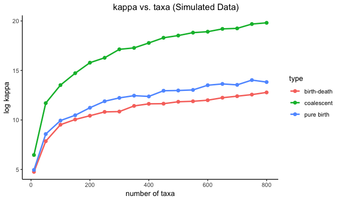

```r
library(ggplot2)
mean.kappa<-apply(log(kappa.array),2,mean)
mean.kappa1<-apply(log(kappa.array1),2,mean)
mean.kappa2<-apply(log(kappa.array2),2,mean)

df <- data.frame(taxa=treesize.array,
               kappa=c(mean.kappa,mean.kappa1,mean.kappa2),
               type=c(rep("birth-death",length(mean.kappa)),rep("coalescent",length(mean.kappa1)),rep("pure birth",length(mean.kappa2))))

legend_title<-"Type"

ggplot(data=df,aes(x=taxa,y=kappa,group=type,color=type))+
  labs(title="                                     kappa vs. taxa (Simulated Data)", y = "log kappa", x="number of taxa")  +
  geom_line(size=1)+
  geom_point( size=2) +
  theme_classic()
```